# Does balancing dataset improve accuracy?

Tiffany Lu (tlu17@illinois.edu)

2020/11/17

## Introduction

Major credit card companies build models to identify frauds in transactions so to protect customer rights and finance. Frauds has always been an issue going on, well before transactions moved online. However, compared to the number of total transactions, the number of frauds is very small. This could pose many problems when we try to build a model to predict and identify fraud transactions as the data itself is biased towards genuine transations. Imagine a model that does not take in any features and it always classify transactions as “genuine”. If only 0.1% of the transactions are fraud, this zero-feature model will have a prediction accuracy of 99.9%! Therefore, we want to build a model that has high recall rate and a good area under the precision recall curve. To do so, we first constructed a base logistic model using the original data. Then, we tried Synthetic Minority Oversampling Technique (SMOTE) to both downsample and upsample the original dataset and feed it to logistic model.

## Methods

### Data

The credit fraud dataset (cc) is from Kaggle (https://www.kaggle.com/mlg-ulb/creditcardfraud) and is collected by Worldline and Machine Learning Group of Universite Libre de Bruxelles. Based on Kaggle, it “contains transactions made by credit cards in September 2013 by european cardholders”. The variable “Class” is our reponse variable, and it will label a transaction as “fraud” or “genuine”. This dataset has 284807 observations and 31 variables, and more details can be found in the appendix. There are no missing data in the dataset; however, the data is inbalanced. Almost all of the observations are not frauds, while only 0.172% of all data is frauds. In this analysis, we will define the “fraud” class as positive and “genuine” class as negative.

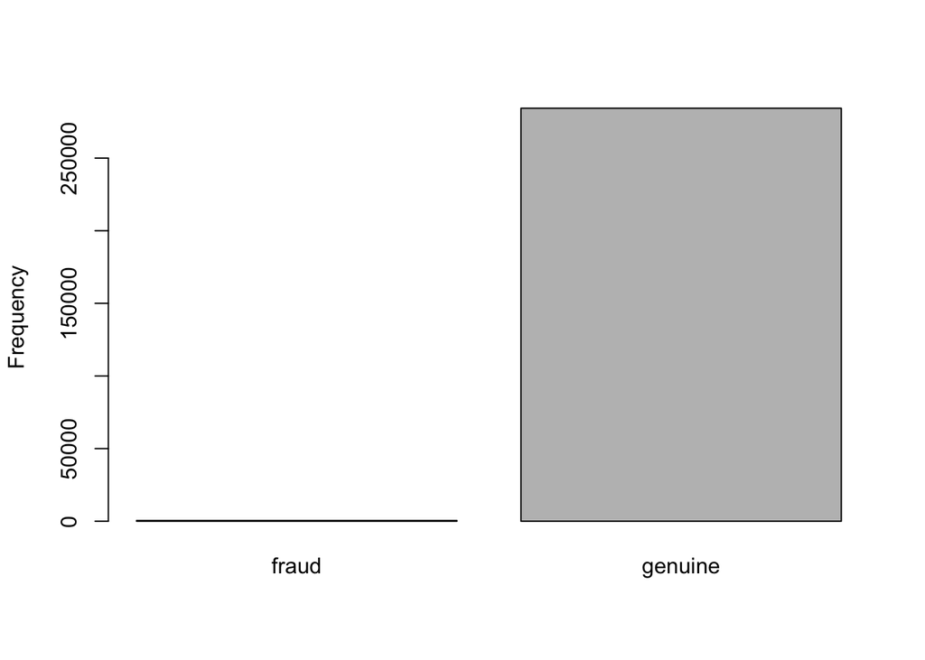

### Modeling

We split the credit fraud data into 8:2 training and testing.

We want to make sure that the training and testing data has an similar proportion of fraud and genuine transactions. Our training dataset has 0.18% fraud instances and our testing dataset has 0.15% fraud instances, which is good.

Now we will first set up a simple logistic model as our baseline. This model uses Class as the response variable and the rest of the variables as features.

Now, since this dataset is unbalanced, we will use SMOTE, or Synthetic Minority Oversampling Technique, to generate a second model that would accurately identify frauds. SMOTE tries to generate synthetic data that mimics the minority class based on k nearest neighbors. In this way, we can get a dataset of more equal occurrences of both classes. The SMOTE library in R allows us to upsample the minority class and to also downsample the majority class.

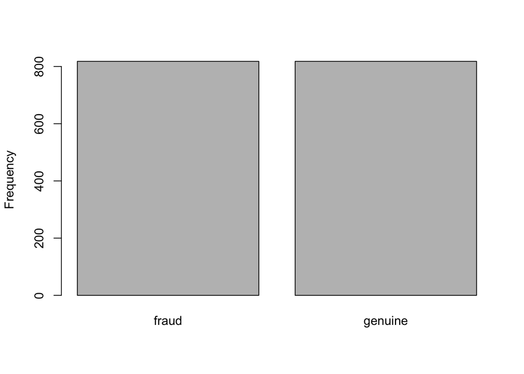

Again, we fit the SMOTE data to a logistic model using Class as response and all other variables as features.

## Results

For the base model of a simple logistic regression with the unbalanced data, we obtained an area under precision-recall curve (AUPRC) of 0.9999934 and a recall of 0.7590361.

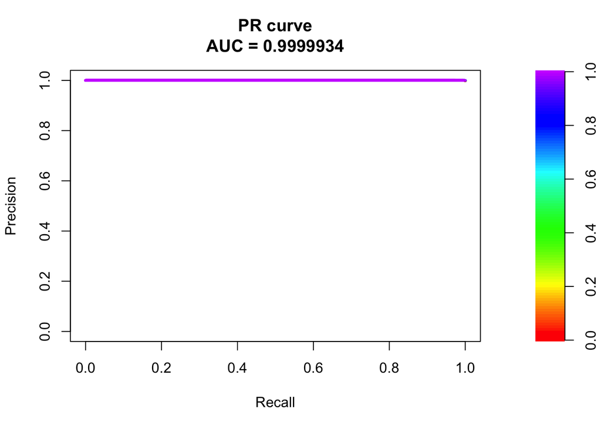

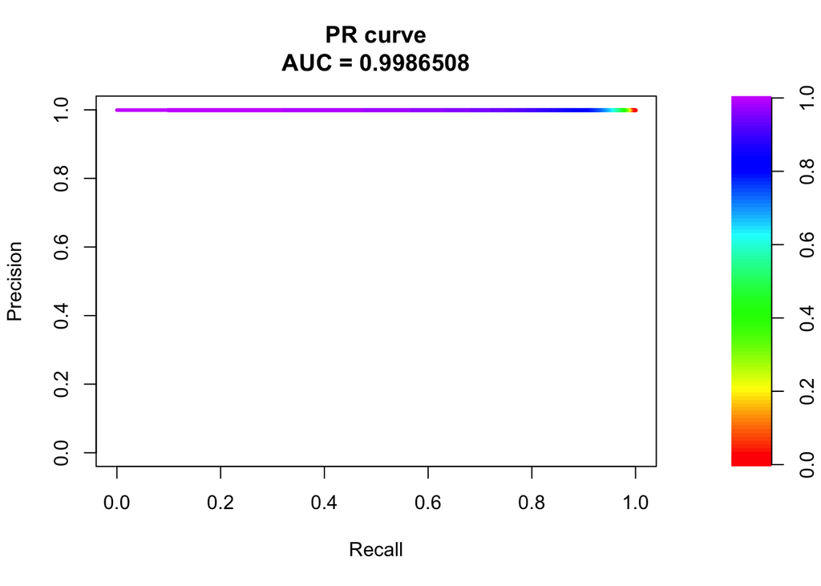

## Discussion

SMOTE have a drawback: it is very prone to overfitting as we are up-sampling the minority. However, it is less prone to overfitting compared to the normal way of replicating minority datas because SMOTE actually give us simulated data that are not replications of the original data. By using up-sampling of minority class and down-sampling of majority class, we get quite good results. However, since we did not do any cross validation for the SMOTE model as we are generating different “samples”, the AUPRC might have some variations.

When training the logistic model SMOTE dataset, we get a warning: “glm.fit: algorithm did not convergeglm.fit: fitted probabilities numerically 0 or 1 occurred”. It might be that the variables are not linearly dependent and is not classifiable. More work can be done on feature selection to resolve this problem.

## Appendix

Time - Number of seconds elapsed between this transaction and the first transaction in the dataset

V1, V2, … V28 - result of PCA Dimensionality reduction

Amount - transaction amount